# Tamanho mínimo de amostra

Arquimedes Macedo. Tiago Rodrigues

```r
library(dplyr)
library(tidyr)
library(readxl)
library(knitr)
library(ggplot2)
library(scales)
library(ggh4x) # used to plot differece between two plots
library(reshape2)
library(gridExtra)
library(vtable)
library(purrr)
library(presize)

knitr::opts_chunk$set(
  out.height = "\\textheight",
  out.width = "\\textwidth",
  out.extra = 'keepaspectratio=true class="chart-image"',
  fig.align = "center"
)
```

```r
theme.base <- theme_minimal(base_size = 11) +
  theme(
    axis.text = element_text(size = 8),
    plot.title = element_text(hjust = 0.5, size = 10, face = "bold"),
    axis.title = element_text(size = 8),
    legend.title = element_text(size = 8),
    panel.grid.major = element_line(colour = "grey90", linewidth = 0.5),
    panel.grid.minor = element_line(colour = adjustcolor("grey90", alpha.f = 0.5), linewidth = 0.25),
    panel.border = element_blank(),
    panel.background = element_blank(),
    plot.background = element_blank(),
    axis.line.x = element_line(colour = "grey"),
    axis.line.y = element_line(colour = "grey"),
  )

theme.no_legend <- theme(legend.position = "none")

theme.no_grid <-  theme(
  panel.grid.major = element_blank(),
  panel.grid.minor = element_blank()
)

theme.no_axis <- theme(
  axis.line.x = element_blank(),
  axis.line.y = element_blank()
)

# Theme for timeseries with legend
apply.theme.ts.legend <- function() {
  list(
    scale_x_date(date_labels = "%b %d", date_breaks = "1 week"),
    theme.base +
      theme(
        axis.text.x = element_text(angle = 45, hjust = 1),
        panel.grid.major.x = element_blank(),
        panel.grid.minor.x = element_blank()
      )
  )
}


# Theme for timeseries
apply.theme.ts <- function() {
  list(
    apply.theme.ts.legend(),
    theme.no_legend
  )
}
```

## Objetivo

Estimar a quantidade média de leads diários, com 80% de confiança, por anunciante, de anúncios de vendas de imóveis na cidade de Florianópolis–SC.

Com um erro máximo de 0.05, usando Amostragem Aleatório Simples sem Reposição (AASs).

*Lead:* é um contato de um cliente em potencial que demonstrou interesse em um produto ou serviço.

IC de 80% foi escolhido devido à falta de informações (descrita logo mais), e também por ser este o valor máximo recomendado pela ABNT para avaliações de imóveis (NBR 14653).

## Metodologia

Almeja-se, a partir de uma lista de anúncios, realizar uma busca diária de anúncios, e, a partir destes dados, estimar a quantidade média de leads.

Portanto:

- **População alvo:** anúncios ativos em um dado dia, na cidade de Florianópolis–SC.
- **População de pesquisa:** anúncios ativos da cidade de Florianópolis–SC entre Janeiro e Julho de 2024.
- **Unidade elementar:** anúncio de venda de imóvel ativo no dia em questão.
- **Característica de interesse:** média diária de leads por anúncio.
- **Estimador:** média amostral.
- **Intervalo de confiança:** 80%.
- **Erro máximo:** 0.05.
- **Método de amostragem:** Amostragem Aleatória Simples sem Reposição (AASs) dos anúncios ativos no dia.
- **Software:** R.
- **Ferramentas:** pacotes do R.
- **Repositório:** [GitHub](https://github.com/Ar-Kan/minimal-sample-size)

Antes de mais nada, contudo, entende-se que há limitações nas informações disponíveis, como:

- O número de leads por anúncio.
- Tempo total que o anúncio ficou ativo.
- A sazonalidade do mercado (oferta e demanda).
- A eficácia do anúncio (qualidade do anúncio, preço, localização, etc).
- A qualidade dos leads (interesse real ou apenas curiosidade).
- A distribuição subjacente dos leads ao longo do tempo.

Desta forma como um estudo piloto, foram obtidos leads diários, entre Janeiro e Julho de 2024, de anúncios de um anunciante na cidade alvo.

### Análise exploratória

O banco de dados é composto por 3 colunas:

- `id_registro`: identificador do lead.
- `data_criado_em`: dia que o lead foi gerado.
- `id_anuncio`: identificador do anúncio.

#### Amostra dos dados

```r
df_leads <- read_excel("dataset/leads.xlsx", col_types = c("numeric", "date", "text"))
df_leads$data_criado_em <- as.Date(df_leads$data_criado_em)
kable(head(df_leads), caption = "Amostra dos dados")
```

Amostra dos dados

| id_registro | data_criado_em | id_anuncio |
| --- | --- | --- |
| 1 | 2024-01-18 | LRB3GK |
| 2 | 2024-01-19 | 4I931S |
| 3 | 2024-01-19 | 4WUWGH |
| 4 | 2024-01-19 | XNI94R |
| 5 | 2024-01-20 | HRDJQG |
| 6 | 2024-01-20 | CH8NIW |

#### Leads diários

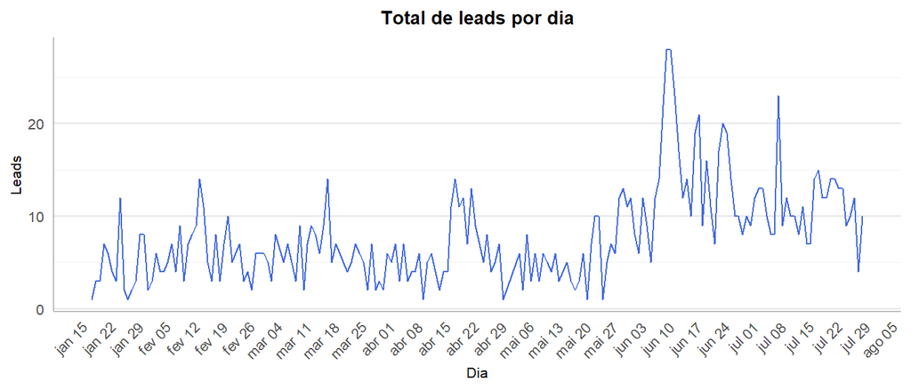

```r
df_leads %>%
  group_by(data_criado_em) %>%
  summarise(leads = n()) %>%
  ggplot(aes(data_criado_em, leads)) +
  geom_line(color = "royalblue", linewidth = 0.5) +
  labs(title = "Total de leads por dia",
       x = "Dia",
       y = "Leads") +
  apply.theme.ts()
```

#### Leads por anúncio

Vamos analisar a média diária de leads por anúncio.

Para isso, dividimos o número total de leads pelo número de anúncios únicos para cada dia.

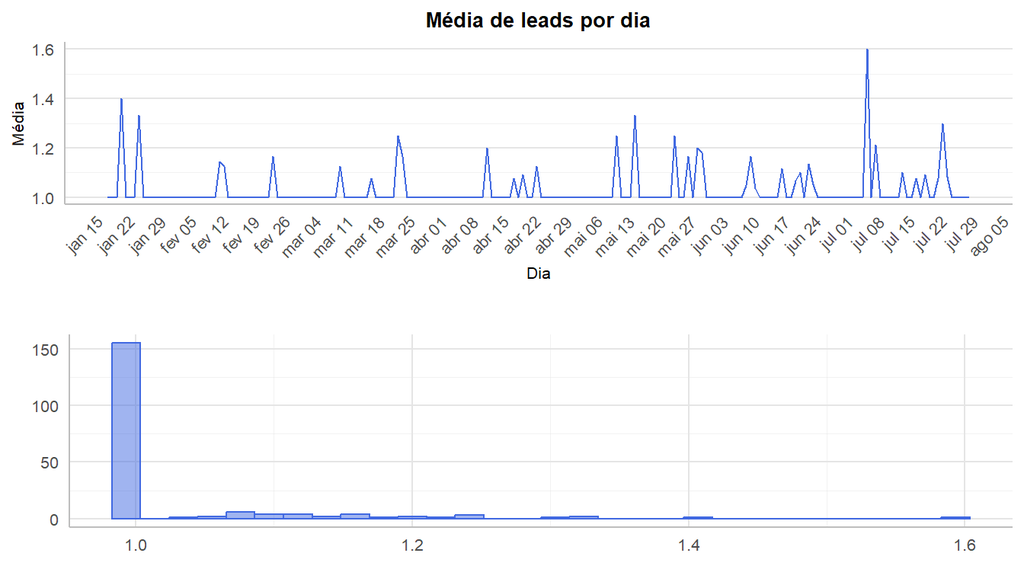

```r
df_leads_incorrect_mean <- df_leads %>%
  group_by(data_criado_em) %>%
  summarise(mean = n()/length(unique(id_anuncio)))

grid.arrange(
  df_leads_incorrect_mean %>%
    ggplot(aes(data_criado_em, mean)) +
    geom_line(color = "royalblue", linewidth = 0.5) +
    labs(title = "Média de leads por dia",
         x = "Dia",
         y = "Média") +
    apply.theme.ts(),
  df_leads_incorrect_mean %>%
    ggplot(aes(mean)) +
    geom_histogram(bins = 30, color = "royalblue", fill = "royalblue", alpha = 0.5) +
    labs(title = "",
         x = "",
         y = "") +
    theme.base + theme.no_legend,
  nrow = 2
)
```

Será que é só isso mesmo?

[figure not shown]

Claro que não! A média diária de leads por anúncio é uma estimativa incorreta, pois não considera a quantidade de anúncios ativos em cada dia, e acaba gerando um viés.

### Estimativa da média

Para corrigir o problema anterior, vamos completar os dados com zeros para os dias sem leads.

Isto é, vamos pegar o primeiro e o último dia que o anúncio teve leads, e criar novos registros entre estas datas, para dias sem lead.

```r
df_leads_complete <- df_leads %>%
  group_by(id_anuncio, data_criado_em) %>%
  summarise(leads = n(), .groups = 'drop') %>%
  group_by(id_anuncio) %>%
  # Creates a list of dataframes by id
  tidyr::nest() %>%
  mutate(
    # Creates a sequence of dates by id
    date_seq = map(data, ~seq(min(.$data_criado_em), max(.$data_criado_em), by = "day")),
    # Completes the missing dates
    data = map2(
      data, date_seq,
      \(data_, seq_) {
        data_ %>%
          complete(data_criado_em = seq_, fill = list(leads = 0))
      }
    )
  ) %>%
  # Removes the auxiliary column
  select(-date_seq) %>%
  # Unnests the data
  unnest(data)

kable(head(df_leads_complete), caption = "Amostra dos dados completados com zero")
```

Amostra dos dados completados com zero

| id_anuncio | data_criado_em | leads |
| --- | --- | --- |
| 00OPP2 | 2024-03-10 | 1 |
| 00SLR7 | 2024-06-29 | 1 |
| 00TPRF | 2024-06-23 | 1 |
| 02NTL4 | 2024-04-20 | 1 |
| 02NTL4 | 2024-04-21 | 0 |
| 02NTL4 | 2024-04-22 | 0 |

A partir desta correção, temos as seguintes médias diárias.

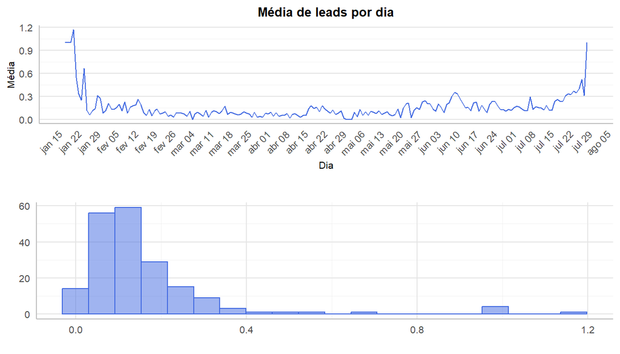

```r
df_leads_daily <- df_leads_complete %>%
  group_by(data_criado_em) %>%
  summarise(mean = mean(leads),
            total_leads = sum(leads),
            active_listings = n_distinct(id_anuncio))

grid.arrange(
  df_leads_daily %>%
    ggplot(aes(data_criado_em, mean)) +
    geom_line(color = "royalblue", linewidth = 0.5) +
    labs(title = "Média de leads por dia",
         x = "Dia",
         y = "Média") +
    apply.theme.ts(),
  df_leads_daily %>%
    ggplot(aes(mean)) +
    geom_histogram(bins = 20, color = "royalblue", fill = "royalblue", alpha = 0.5) +
    labs(title = "",
         x = "",
         y = "") +
    theme.base + theme.no_legend,
  nrow = 2
)
```

Mas não está totalmente correto…

[figure not shown]

Lembrando que esta é uma aproximação e não corresponde totalmente ao que de fato aconteceu, para computar a verdadeira média, precisaríamos da listagem de todos os anúncios ativos no dia.

Nota-se, também, que existem pontos extremos no início e no fim da série, isso pode ser explicado por anúncios que estavam ativos antes do início do período analisado ou que apareceram um pouco antes do fim.

Portanto, vamos analisar apenas entre 01/02/2024 e 20/07/2024.

```r
df_leads_complete_filtered <- df_leads_complete %>%
  filter(between(data_criado_em, as.Date("2024-02-01"), as.Date("2024-07-20")))

df_leads_daily_filtered <- df_leads_complete_filtered %>%
  group_by(data_criado_em) %>%
  summarise(mean = mean(leads),
            total_leads = sum(leads),
            active_listings = n_distinct(id_anuncio))

sumtable(df_leads_complete_filtered, add.median = T, title = "Registros corrigidos")
```

Registros corrigidos

| Variable | N | Mean | Std. Dev. | Min | Pctl. 25 | Pctl. 50 | Pctl. 75 | Max |
| --- | --- | --- | --- | --- | --- | --- | --- | --- |
| leads | 11253 | 0.12 | 0.34 | 0 | 0 | 0 | 0 | 4 |

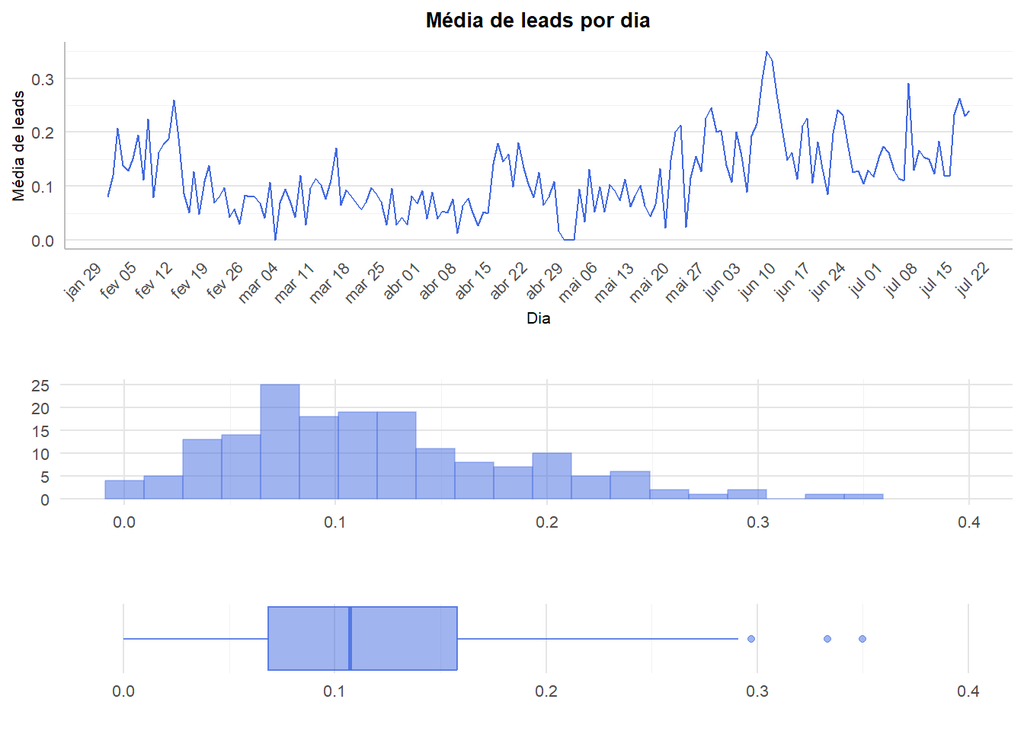

```r
grid.arrange(
  df_leads_daily_filtered %>%
    ggplot(aes(data_criado_em, mean)) +
    geom_line(color = "royalblue", linewidth = 0.5) +
    labs(title = "Média de leads por dia",
         x = "Dia",
         y = "Média de leads") +
    apply.theme.ts(),
  df_leads_daily_filtered %>%
    ggplot(aes(mean)) +
    coord_cartesian(xlim = c(-0.01, 0.4)) +
    geom_histogram(bins = 20, color = adjustcolor("royalblue", alpha.f = 0.3), fill = "royalblue", alpha = 0.5) +
    labs(title = "",
         x = "",
         y = "") +
    theme.base + theme.no_legend + theme.no_axis +
    theme(panel.grid.minor.y = element_blank()),
  df_leads_daily_filtered %>%
    ggplot(aes(mean)) +
    coord_cartesian(xlim = c(-0.02, 0.4)) +
    geom_boxplot(color = adjustcolor("royalblue", alpha.f = 0.8), fill = "royalblue", alpha = 0.5) +
    labs(title = "",
         x = "",
         y = "") +
    theme.base + theme.no_legend + theme.no_axis +
    theme(axis.text.y = element_blank(),
          axis.ticks.y = element_blank(),
          panel.grid.major.y = element_blank(),
          panel.grid.minor.y = element_blank()),
  nrow = 3,
  heights = c(3, 2, 1.5)
)
```

```r
leads_daily_mean <- mean(df_leads_complete_filtered$leads)
leads_daily_sd <- sd(df_leads_complete_filtered$leads)

leads_mean_of_means <- mean(df_leads_daily_filtered$mean)
leads_sd_of_means <- sd(df_leads_daily_filtered$mean)
mean_active_listings <- ceiling(mean(df_leads_daily_filtered$active_listings))

sumtable(df_leads_daily_filtered, add.median = T, title = "Média de leads por dia")
```

Média de leads por dia

| Variable | N | Mean | Std. Dev. | Min | Pctl. 25 | Pctl. 50 | Pctl. 75 | Max |
| --- | --- | --- | --- | --- | --- | --- | --- | --- |
| mean | 171 | 0.12 | 0.069 | 0 | 0.068 | 0.11 | 0.16 | 0.35 |
| total_leads | 171 | 7.8 | 5.1 | 0 | 4 | 7 | 10 | 28 |
| active_listings | 171 | 66 | 14 | 25 | 58 | 71 | 76 | 93 |

## Resultados

Assim, apesar dos pesares, temos uma média de `~0.118` leads por dia, com um desvio padrão de `~0.337`. Além disso, a média das médias diárias é de `~0.118` com um desvio padrão de `~0.069`.

### Tamanho da amostra

Calculamos que o tamanho da amostra, a partir da equação

$$\begin{aligned}
n' &\ge \left(Z_{\alpha / 2} \frac{\sigma}{\text{e}}\right)^2 \\
n &= n' \cdot \frac{N-n}{N-1}
\end{aligned}$$

onde, $Z_{\alpha / 2}$ é o valor crítico da distribuição normal, $\text{e}$ é a margem de erro, $\sigma$ é o desvio padrão, $N$ é o tamanho da população, $n'$ é o tamanho da amostra com amostra aleatória simples com reposição (AASc), e, $n$ é o tamanho da amostra sem reposição (AASs).

Lembrando que queremos estimar a média de leads diários a partir de uma amostra de anúncios.

Mas qual parâmetro devemos usar para o desvio padrão? O desvio padrão dos leads diários ou o desvio padrão das médias diárias?

- **Desvio padrão dos leads diários**: indica o quanto os leads variam durante todo o período.
- **Desvio padrão das médias diárias**: indica o quanto as médias diárias variam de um dia para o outro.

O nosso objetivo é amostrar anúncios ativos no dia, e não todos, desta forma, escolhemos o desvio padrão das médias diárias.

**Nota:** neste caso não há resposta certa, haja visto que estamos trabalhando com uma dimensão a mais, o tempo. Desta forma, se escolhermos o desvio padrão dos leads diários, iremos ignorar que existem dias. Por outro lado, se escolhermos o desvio padrão das médias diárias, estaremos ignorando que existem anúncios.

```r
confidence <- 0.8
z_quartil <- abs(qnorm((1 - confidence) / 2))
max_error <- 0.05
sigma <- leads_sd_of_means
size_population <- mean_active_listings

computed_sample_size_aasc <- (z_quartil * sigma / max_error)^2
computed_sample_size <- ceiling(
  computed_sample_size_aasc *
    (size_population - computed_sample_size_aasc) / (size_population - 1)
)
```

**Ta-dá!** Para obter uma margem de erro de `0.05` com `80%` de confiança, utilizando AASs,  
precisamos de uma amostra de `4` anúncios por dia.

[figure not shown]

### Análise do erro

Vamos analisar o erro da média de leads diários, a partir do tamanho da amostra calculado.

```r
sample_repetitions <- 20

df_leads_daily_error <- df_leads_complete_filtered %>%
  group_by(data_criado_em) %>%
  summarise(lead_mean = mean(leads),
            lead_sd = sd(leads),
            leads = list(leads),
            active_listings = n_distinct(id_anuncio)) %>%
  rowwise() %>%
  mutate(
    samples = list(replicate(sample_repetitions, sample(leads, computed_sample_size, replace = F), simplify = F)),
    samples_mean = list(map_dbl(samples, mean)),
    samples_error = list(map_dbl(samples_mean, ~ abs(.x - lead_mean))),
    min_mean = min(samples_mean),
    max_mean = max(samples_mean),
    mean_mean = mean(samples_mean),
    sd_mean = sd(samples_mean),
    min_error = min(samples_error),
    max_error = max(samples_error),
    mean_error = mean(samples_error)
  ) %>%
  select(-samples, -samples_mean, -samples_error, -leads)

sample_mean_means <- mean(df_leads_daily_error$mean_mean)
sample_mean_errors <- mean(df_leads_daily_error$mean_error)

colnames_lookup <- c(
  "Média das médias reais" = "lead_mean",
  "Média das médias amostrais" = "mean_mean",
  "Erro médio" = "mean_error"
)
sumtable(df_leads_daily_error %>%
           select(lead_mean, mean_mean, mean_error) %>%
           rename(all_of(colnames_lookup)),
         add.median = T, title = "Erro da média de leads diários")
```

Erro da média de leads diários

| Variable | N | Mean | Std. Dev. | Min | Pctl. 25 | Pctl. 50 | Pctl. 75 | Max |
| --- | --- | --- | --- | --- | --- | --- | --- | --- |
| Média das médias reais | 171 | 0.12 | 0.069 | 0 | 0.068 | 0.11 | 0.16 | 0.35 |
| Média das médias amostrais | 171 | 0.11 | 0.076 | 0 | 0.062 | 0.11 | 0.15 | 0.4 |
| Erro médio | 171 | 0.12 | 0.047 | 0 | 0.096 | 0.13 | 0.15 | 0.3 |

Olhando a tabela acima, vemos que, com uma amostra de `4` anúncios, a média das médias amostrais de leads diários é de `0.11` leads, com um erro médio de `0.124` leads.

Ou seja, o valor é bem próximo da média real, no entanto, o erro médio é bem maior que `0.05`.

Mas pera aí…

[figure not shown]

Ao analisarmos as estimativas globalmente, ficamos com a impressão de que o tamanho da amostra é suficiente. Contudo, nosso objetivo final é estimar a média diária de leads. Desta forma, precisamos analisar o erro ao nível diário.

Vamos, portanto, analisar o intervalo de confiança da estimativa.

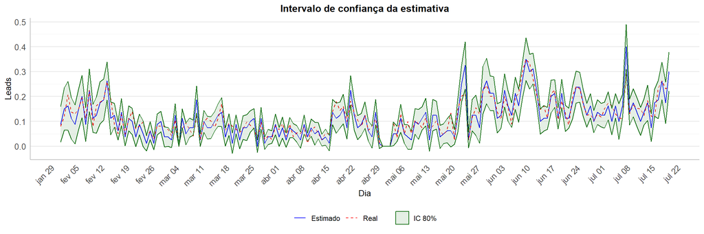

```r
z_quartil <- z_quartil

df_leads_daily_error %>%
  mutate(
    error = z_quartil * lead_sd / sqrt(active_listings)
  ) %>%
  ggplot(aes(data_criado_em)) +
  geom_line(aes(y = mean_mean, color = "Estimado")) +
  geom_line(aes(y = lead_mean, color = "Real"), linetype = "dashed") +
  geom_ribbon(aes(ymin = mean_mean - error, ymax = mean_mean + error, linetype = 'IC 80%'),
              fill = "darkgreen", alpha = 0.1, color = "darkgreen") +
  labs(title = "Intervalo de confiança da estimativa",
       x = "Dia",
       y = "Leads",
       linetype = NULL) +
  scale_color_manual(name = NULL,
                     values = c("Estimado" = "blue", "Real" = "red")) +
  apply.theme.ts.legend() +
  theme(legend.position = "bottom",
        axis.text = element_text(size = 10),
        plot.title = element_text(size = 12),
        axis.title = element_text(size = 10),
        legend.title = element_text(size = 10))
```

E, analisar, também, o erro ao nível diário.

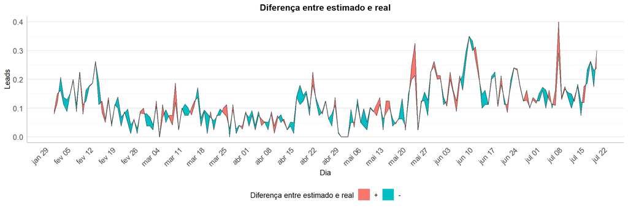

```r
df_leads_daily_error %>%
  ggplot(aes(data_criado_em)) +
  stat_difference(aes(ymin = lead_mean, ymax = mean_mean)) +
  scale_fill_discrete(name = "Diferença entre estimado e real") +
  geom_line(aes(y = mean_mean), alpha = 0.5, linewidth = 0.5) +
  geom_line(aes(y = lead_mean), alpha = 0.5, linewidth = 0.5) +
  labs(title = "Diferença entre estimado e real",
       x = "Dia",
       y = "Leads") +
  apply.theme.ts.legend() +
  theme(legend.position = "bottom",
        axis.text = element_text(size = 10),
        plot.title = element_text(size = 12),
        axis.title = element_text(size = 10),
        legend.title = element_text(size = 10))
```

```r
# percentage of days where the confidence interval contains the real mean
df_confidence_interval <- df_leads_daily_error %>%
  mutate(
    error = z_quartil * lead_sd / sqrt(active_listings),
    ci_contains_mean = ifelse(lead_mean >= mean_mean - error & lead_mean <= mean_mean + error, "yes", "no")
  ) %>%
  group_by(ci_contains_mean) %>%
  summarise(days = n()) %>%
  mutate(percentage = round(days / sum(days) * 100, 2))

percentage_within_ci <- df_confidence_interval %>%
  filter(ci_contains_mean == "yes") %>%
  pull(percentage)

kable(df_confidence_interval, caption = "Porcentagem de dias onde o intervalo de confiança contém a média real")
```

Porcentagem de dias onde o intervalo de confiança contém a média real

| ci_contains_mean | days | percentage |
| --- | --- | --- |
| no | 19 | 11.11 |
| yes | 152 | 88.89 |

Observa-se que, em média, a amostra segue o mesmo padrão da média real. Além disso, o intervalo de confiança de 80% da estimativa contém a média real em `88.89%` dos dias.

Ou seja, analisando até aqui, fica fácil dizer que a amostra parece ser suficiente para estimar a média diária de leads. Vamos então analisar o erro diário absoluto.

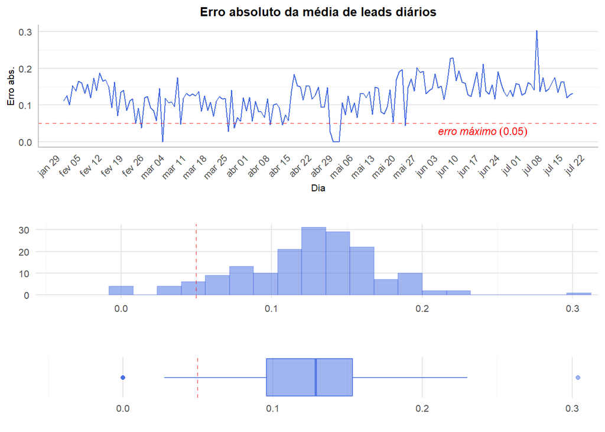

```r
grid.arrange(
  df_leads_daily_error %>%
    ggplot(aes(data_criado_em, mean_error)) +
    geom_line(color = "royalblue", linewidth = 0.5) +
    geom_hline(yintercept = max_error, color = "red", linetype = "dashed", alpha = 0.5) +
    annotate("text", x = as.Date("2024-06-20"), y = max_error,
             label = paste('italic("erro máximo ") (', max_error, ')'), color = "red", parse = T,
             vjust = 1.2, size = 3) +
    labs(title = "Erro absoluto da média de leads diários",
         x = "Dia",
         y = "Erro abs.") +
    apply.theme.ts(),
  df_leads_daily_error %>%
    ggplot(aes(mean_error)) +
    coord_cartesian(xlim = c(-0.04, 0.3)) +
    geom_histogram(bins = 20, color = adjustcolor("royalblue", alpha.f = 0.3), fill = "royalblue", alpha = 0.5) +
    geom_vline(xintercept = max_error, color = "red", linetype = "dashed", alpha = 0.5) +
    labs(title = "",
         x = "",
         y = "") +
    theme.base + theme.no_legend + theme.no_axis +
    theme(panel.grid.minor.y = element_blank()),
  df_leads_daily_error %>%
    ggplot(aes(mean_error)) +
    coord_cartesian(xlim = c(-0.05, 0.3)) +
    geom_boxplot(color = adjustcolor("royalblue", alpha.f = 0.8), fill = "royalblue", alpha = 0.5) +
    geom_vline(xintercept = max_error, color = "red", linetype = "dashed", alpha = 0.5) +
    labs(title = "",
         x = "",
         y = "") +
    theme.base + theme.no_legend + theme.no_axis +
    theme(axis.text.y = element_blank(),
          axis.ticks.y = element_blank(),
          panel.grid.major.y = element_blank(),
          panel.grid.minor.y = element_blank()),
  nrow = 3,
  heights = c(3, 2, 1.5)
)
```

Apesar de dar a impressão de estar correto, o gráfico nos mostra que estamos errando além do esperado a maioria das vezes. Isso indica que a amostra não é suficiente para garantir a precisão desejada.

Outro fator que indica a má qualidade das inferências realizadas é que o erro segue o mesmo padrão que a série temporal. Isso indica que o erro não é aleatório.

Consequentemente, não podemos ter confiança que teremos uma estimativa precisa da média diária de leads.

Mas, o que pode ter dado errado então?

### Causas do erro

- **Variabilidade dos dados**: para calcular o tamanho da amostra utilizamos a média de todas as médias diárias, desta forma, perdemos a informação de que há dias com alta variabilidade relativa. O ideal, certamente, seria calcular o tamanho da amostra para cada dia, no entanto, isso faria com que o resultado fosse impraticável. Pois necessitaríamos da média e desvio padrão de cada um desses dias.
- **Independência**: na verdade, tudo realizado até aqui foi baseado na premissa de que os dados são independentes. No entanto, estamos lidando com uma série temporal, e, portanto, os dados são dependentes do tempo. Isso, por si só, já invalida a técnica de estimação do tamanho da amostra utilizada.

## Sugestão de tamanho da amostra

Para trabalhos futuros sugerimos que **não** utilize as técnicas de estimação de tamanho de amostra apresentadas neste trabalho. Em vez disso, sugerimos que sejam utilizadas técnicas de amostragem próprias para séries temporais.

No entanto, por questões de completude, caso não houvesse teporalidade nos dados e presumindo independência, o tamanho da amostra necessário para estimar a média diária de leads com erro máximo de 0.05 e confiança de 80% pode ser calculada por intermédio do pacote `presize`:

```r
sample_size_ <- presize::prec_mean(mean = 0.12, sd = 0.0689*2, conf.width = 0.05*2, conf.level = 0.8)
paste("O tamanho da amostra necessário é de", ceiling(sample_size_$n), "anúncios")
```

```
## [1] "O tamanho da amostra necessário é de 14 anúncios"
```

[figure not shown]